# Understanding Feature Interactions in XGBoost

Omkar Shetty

07/11/2020

## Background

While building a ML model, it is common to come across features at different levels of granularity. For instance, in the retail world, it is pretty common to build models that generate predictions for each product in a store for each day (also known as an item-location-day granularity) - examples include sales predictions, predicting on-shelf availability etc. However, sometimes it is observed that features of a different granularity (location based features such as store size or location-day features like total sales for a day) end up as top features in the feature importance - which at face value can be difficult to understand, since a large number of rows would have the same value.

So the question now (at least for me) is that is this due to some feature interactions that the model is capturing implicitly.

## Objective

The goal of this notebook is to understand how xgboost handles feature interactions (and a secondary question is to understand if it is better to capture feature interactions explicitly and separately or it doesn’t really a big difference)

```
##           used (Mb) gc trigger (Mb) max used (Mb)
## Ncells  542060 29.0    1238077 66.2   621331 33.2
## Vcells 1020678  7.8    8388608 64.0  1600178 12.3
```

## Simulation Example

We start by defining a config for our simulation dataset. This will also include the parameters of the xgboost model to be built.

```r
config <- list(
   N = 1e6                  # no of rows in the dataset
  ,train_perc = 0.7         # % of dataset to be used for training the model
  ,x1_vals = c(50,100,150)  # pool of possible values to draw from
  ,seed = 7112020
)
```

### Creating the dataset

```r
set.seed(config$seed)

ttl_dat <- data.table(
   x1 = sample(x = config$x1_vals,size = config$N, replace = T)       # less granular feature, assumed common for a large no of rows
  ,x2 = runif(n = config$N, min = 0, max = 10)       # more granular feature
  ,x3 = rnorm(n = config$N, mean = 10, sd = 10)      # 3rd feature, shoudn't directly impact y
)

# Specifying dependent variable

ttl_dat[,y := dplyr::case_when( x1 == 50 & x2 <= 4 ~ 1,
                                x1 == 150 & x2 <8 ~ 1,
                                TRUE ~ 0)]
```

Note that the feature x3 is specifically not used for defining the dependent variable.

### Pre-processing the data

Here we split the data into train and test and set it up to be used for training an xgboost model.

```r
train_ids <- sample(x = nrow(ttl_dat), size = floor(nrow(ttl_dat)*config$train_perc), replace = F)

train_dat <- ttl_dat[train_ids]
test_dat <- ttl_dat[!train_ids]

feats <- c('x1','x2','x3')

train_mat <- data.matrix(train_dat[,..feats])
test_mat <- data.matrix(test_dat[,..feats])
```

### Building an xgboost model

Here we make a simple xgboost model (for this example we mostly use out of the box parameters)

```r
fit <- xgboost::xgboost(data = train_mat,
                        objective = "binary:logistic",
                        label = train_dat$y,
                        nrounds = 500,
                        early_stopping_rounds = 20,
                        verbose = 0)

# How 'good' is the model ?

test_dat[,xgb_pred := predict(object = fit, newdata = test_mat)]

test_dat[,Metrics::auc(actual = y, predicted = xgb_pred)]
```

```
## [1] 1
```

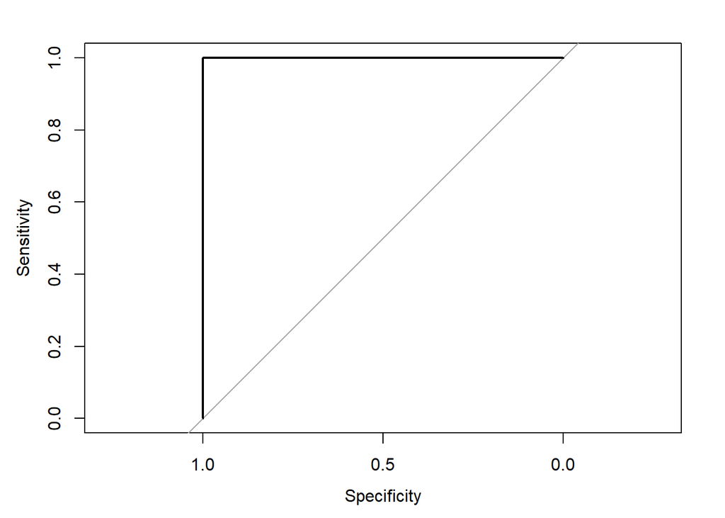

```
##
## Call:
## roc.default(response = test_dat$y, predictor = test_dat$xgb_pred,     plot = T)
##
## Data: test_dat$xgb_pred in 179616 controls (test_dat$y 0) < 120384 cases (test_dat$y 1).
## Area under the curve: 1
```

```r
pROC::roc(test_dat$y, test_dat$xgb_pred, plot = T)
```

The model seems to be capturing the behaviour perfectly as seen by the ROC curve and the associated AUC value (hardly surprising).

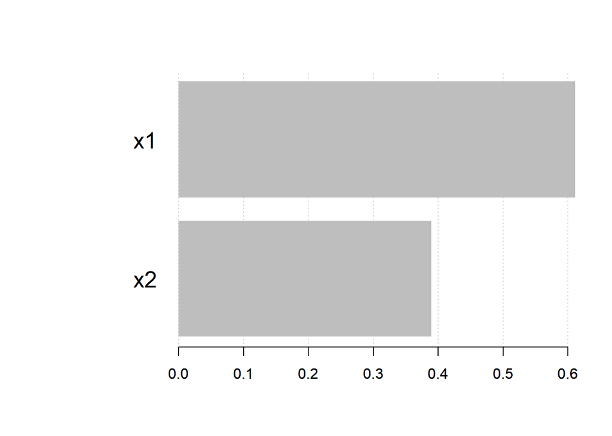

```r
xgb.plot.importance(xgb.importance(model = fit))
```

Looking at the feature importance plot, a couple of key takeaways for me : 1. It is possible to get a less granular feautr be the most important while predicting a more granular response variable 2. Although it may be possible, it may not always be likely - in this example, the definition of the response variable had to be tweaked (a couple of times) to ensure that the feature x1 was called out as more important than x2. 3. To no one’s surprise, feature x3 is completely discarded by the model.

### What does the model tree plot looks like

To verify that the model is indeed capturing the feature interaction, we plot one of the trees NOTE : Based on the documentation, it seems more appropriate to use xgb.plot.multi.trees, however I was unable to represent the model the way I wanted to. So using a single tree depiction (which given the simplicity of the model shouldn’t be too bad)

```r
xgb.plot.tree(feature_names = c('x1','x2'), model = fit,trees = 20)
```

[interactive chart not shown]

As can be seen from the plot, the model seems to be capturing the interaction pretty accurately.

So far so good !

Finally, to avoid questions around feature selection, can we explicitly specify an interaction term in the model definition ?

## Interaction Feature

```r
# Defining a new interaction feature - which will now be different for different rows
# This may or may not have an interpretaion by itself

train_dat[,int_x := x1*x2]
test_dat[,int_x := x1*x2]

# THe previous feature x1 will now be replaced with int_x to rebuild the model.

feats_alt <- c('int_x','x2')

train_mat_alt <- data.matrix(train_dat[,..feats_alt])
test_mat_alt <- data.matrix(test_dat[,..feats_alt])
```

### Re-building a model

```r
fit_alt <- xgboost::xgboost(data = train_mat_alt,
                        objective = "binary:logistic",
                        label = train_dat$y,
                        nrounds = 500,
                        early_stopping_rounds = 20,
                        verbose = 0)

# How 'good' is the model ?

test_dat[,xgb_pred_alt := predict(object = fit_alt, newdata = test_mat_alt)]

test_dat[,Metrics::auc(actual = y, predicted = xgb_pred_alt)]
```

```
## [1] 1
```

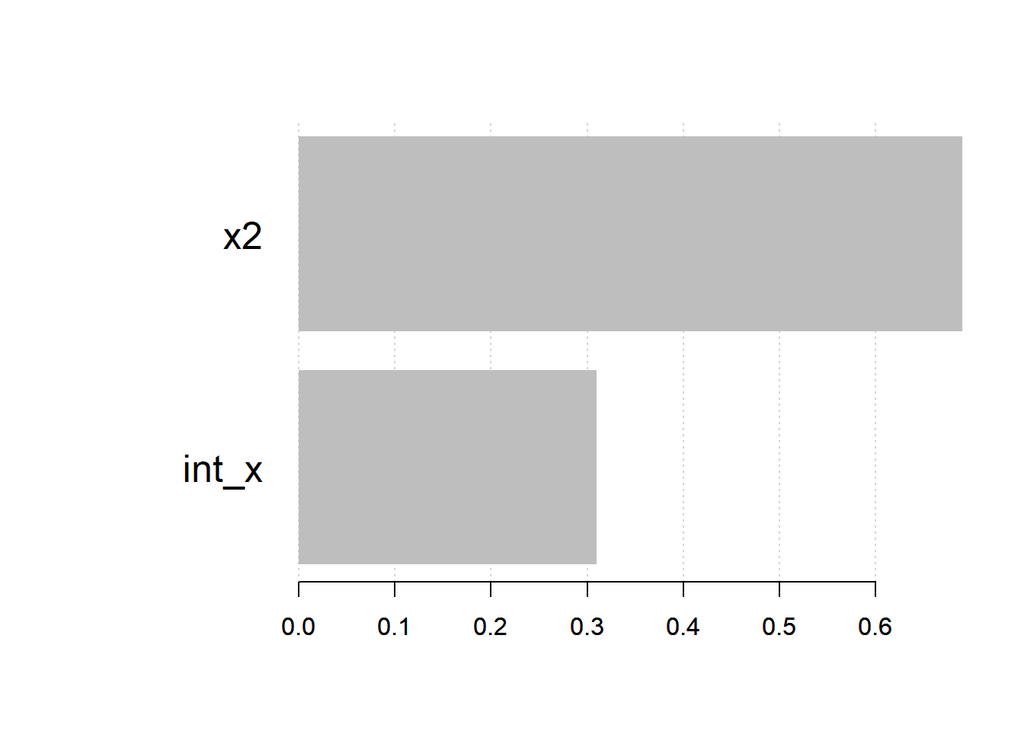

```r
xgb.plot.importance(xgb.importance(model = fit_alt))
```

The feature importance now changes to show x2 as the more dominant feature (although again the callout is that the model performance itself remain unchanged)

```r
test_dat[,.N,.(xgb_pred > 0.5,xgb_pred_alt> 0.5)]
```

| xgb_pred | xgb_pred_alt | N |
| --- | --- | --- |
| TRUE | TRUE | 120382 |
| FALSE | FALSE | 179612 |
| FALSE | TRUE | 4 |
| TRUE | FALSE | 2 |

For the vast majority of cases, the two models are in agreement with each other. For kicks, we look at the miniscule number of rows where the predictions dont match.

```r
test_dat[(xgb_pred < 0.5 & xgb_pred_alt > 0.5) | (xgb_pred > 0.5 & xgb_pred_alt < 0.5), ]
```

| x1 | x2 | x3 | y | xgb_pred | int_x | xgb_pred_alt |
| --- | --- | --- | --- | --- | --- | --- |
| 100 | 0.0006814231 | 5.5054209 | 0 | 0.3543496 | 0.06814231 | 0.6709535 |
| 150 | 0.0001913379 | 0.1644503 | 1 | 0.6456534 | 0.02870068 | 0.2780688 |
| 100 | 0.0413666666 | -5.7569850 | 0 | 0.3543496 | 4.13666666 | 0.7746181 |
| 150 | 0.0001297449 | 9.2619705 | 1 | 0.6456534 | 0.01946173 | 0.2657939 |
| 100 | 0.0007008435 | 2.5678288 | 0 | 0.3543496 | 0.07008435 | 0.6709535 |
| 100 | 0.0001340266 | 11.0152269 | 0 | 0.3543496 | 0.01340266 | 0.8844977 |

Interestingly, in all 6 cases here the 1st model ends up being more accurate than the 2nd one.

Can we plot the new model, similar to the first one ?

```r
xgb.plot.tree(feature_names = c('x2','int_x'), model = fit_alt,trees = 20)
```

[interactive chart not shown]

We can, but it doesnt look as easily interpretable (compared to the first model)

## Comparing the prediction scores from the model itself

Does the different setup of the model impact the distribution of scores ?

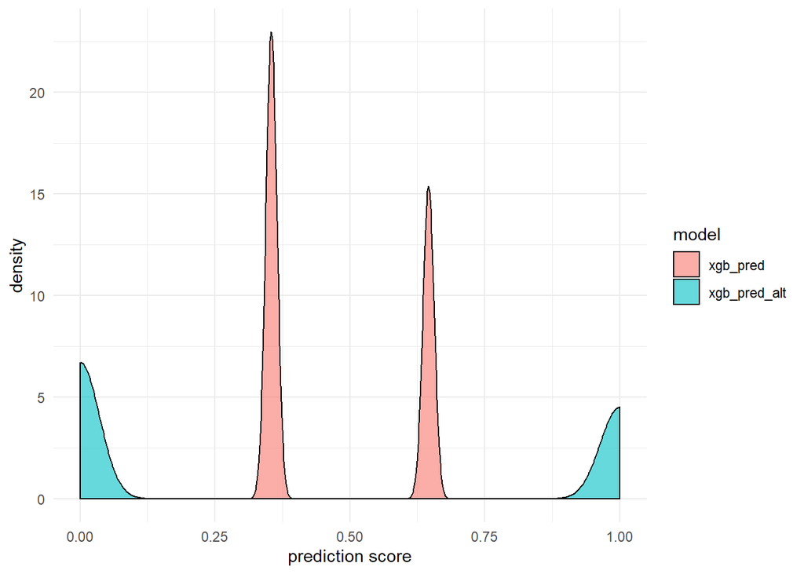

```r
test_m <- melt(data = test_dat, id.vars = c('x1','x2','int_x'), measure.vars = c('xgb_pred','xgb_pred_alt'),
               variable.name = 'model',value.name = 'prediction')

ggplot(data = test_m) +
  geom_density(aes(x = prediction, fill = model), alpha = 0.6) +
  labs(x = 'prediction score') +
  theme_minimal()
```

The scores themselves do seem to be impacted - with the model based on the interaction feature having a wider separation between the prediction classes. This property might be useful in a more complex scenario - however for this example, the gap doesnt really matter as much since a threshold of 0.5 provides a pretty clean split between the classes.

## Conclusion

The conclusions and take-aways for me : 1. The feature importance by itself might not provide a complete picture. Although x1 was a key feature in our first model, it was only the interaction with the x2 feature that gave it the predictive power. 2. If we are not comfortable with using low granularity features directly, there is always an option of deriving secondary features. From these examples at least, the model didnt really suffer from a major loss of predictive power.